# Fundamentals of Optimization

Author

Marcel Angenvoort

Published

July 1, 2025

Abstract

Keywords

math, optimization, julia, 90-01, 90C30

## Optimization Problems

An Optimization problem in **standard form** is given by:

$$\begin{aligned}
\text{minimize} &\quad f(\mathbf{x}) \\
\text{s.t.} \quad
\mathbf{h}(\mathbf{x}) &= 0 \\
\mathbf{g}(\mathbf{x}) &\leq 0
\end{aligned}$$

. . .

We call $\mathbf{x}^\ast$ an **optimal point** if it solves the optimization problem, and $p^\ast$ is the corresponding **optimal value**.

. . .

Examples: (see notes 1)

- box constraints
- maximization problems
- equivalence of optimization problems

### Transforming the optimization problem

We can transform the optimization problem from the standard form to the **epigraph form**:

$$\begin{aligned}
\text{minimize} \quad &t \\
\text{s.t.} \quad
f(\mathbf{x}) - t &\leq 0 \\
\qquad \mathbf{g}(\mathbf{x}) &\leq \mathbf{0} \\
\qquad \mathbf{h}(\mathbf{x}) &= \mathbf{0}
\end{aligned}$$

. . .

Geometrically, we can interpret this as an optimisation problem in ‘graph space’. Find $x$ and $t$ such that $(x, t)$ belongs to the epigraph of $f$, and such that $x$ belongs to the feasible region.

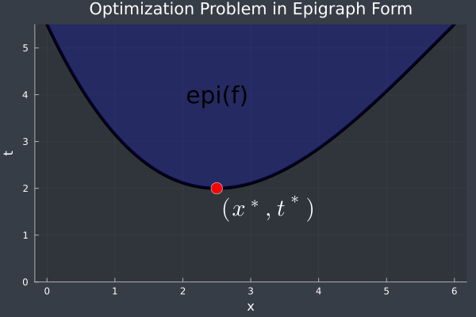

Figure 1: Optimization problem in Epigraph form

```julia
using Plots
using LaTeXStrings
theme(:dark)

#default(size = (800, 600))  # set default plot size

# Define the function f(x)
f(x) = - 0.0457x^3 + 0.7886x^2 - 3.0857x + 5.5

# Define the x-range
x_range = 0:0.01:6

# Find the minimum point (x*, f(x*)) for the visualization
x_star = 2.5

# Create the plot
plot(x_range, f.(x_range),
    label = "f(x)",
    linewidth = 4,
    color = :black,
    xlabel = "x",
    ylabel = "t",
    title = "Optimization Problem in Epigraph Form",
    ylim = (0, 5.5),
    legend = false,
)

# Fill the area above the graph in blue to represent epi(f)
plot!(x_range, f.(x_range),
  fillrange = 5.5, fillalpha = 0.2, c = :blue, linealpha = 0)

# Add the label "epi(f)" in the middle of the blue area
annotate!(2.5, 4, text("epi(f)", :center, 20, :black))
annotate!(2.6, 1.9, text(L"(x^\ast, t^\ast)", :left, :top, :white, 20))

# Add the red point at (x*, f(x*))
scatter!([x_star], [f(x_star)],
    markersize = 8,
    markercolor = :red,
)
```

Consider the following optimization problem:
$$\begin{aligned}
\text{minimize} \quad&f(\mathbf{x}_1, \mathbf{x}_2) \\
\text{subject to}\quad &\mathbf{g}(\mathbf{x_1}) \leq 0 \\
&\tilde{\mathbf{g}}(\mathbf{x_2}) \leq 0
\end{aligned}$$

. . .

If we define the function $\tilde{f}$ via
$$\tilde{f}(\mathbf{x}) := \inf \bigl\{ f(\mathbf{x}, \mathbf{z}) : \tilde{g}(\mathbf{z}) \leq \mathbf{0} \bigr\},$$

. . .

then the optimization problem is equivalent to:
$$\begin{aligned}
\text{minimize} \quad &\tilde{f}(\mathbf{x}) \\
\text{subject to} \quad &\mathbf{g}(\mathbf{x}) \leq 0
\end{aligned}$$

. . .

Example: see notes 2.

### Convex Optimization

A convex optimization problem has the form:

$$\begin{aligned}
\text{minimize}\quad &f(\mathbf{x}) \\
\text{s.t.} \quad &\mathbf{g}(\mathbf{x}) \leq 0 \\
&\mathbf{a}^\mathrm{T} \mathbf{x} = b
\end{aligned}$$

where:

- the objective function $f$ is convex,
- the inequality constraints $\mathbf{g}$ are convex,
- the equality constraints $\mathbf{h}$ are affine

### Optimality criterion

Let
$$X := \bigl \{ \mathbf{x} \in \mathbb{R}^n: \, \mathbf{g}(\mathbf{x}) \leq \mathbf{0}, \, \mathbf{h}(\mathbf{x}) = \mathbf{0} \bigr \}$$
be the **feasible set**.

Then the following optimality criterion holds:

. . .

**ImportantOptimality Criterion**

The point $x^\ast$ is an optimal point for the optimization problem if and only if
$$\nabla f(\mathbf{x}^\ast) \cdot ( \mathbf{y} - \mathbf{x}^\ast ) \geq 0 \quad \forall \mathbf{y} \in X$$

*Proof*. See notes 3.

### Linear Programming

A **linear program** is an optimization problem where the objective function is linear and the constraint functions are affine.

$$\begin{aligned}
\text{minimize} \quad & \mathbf{c}^\mathrm{T} \mathrm{x} + \mathbf{d} \\
\text{s.t.} \quad& B\mathbf{x} \leq \mathbf{h}, \\
&A\mathbf{x} = \mathbf{b}
\end{aligned}$$

. . .

By introducing a **slack variable** $s$, this can be transformed into a **linear program in standard form**:

. . .

$$\begin{aligned}
\text{minimize} \quad \mathbf{c}^\mathrm{T} \mathbf{x} \\
\begin{aligned}
\text{s.t.} \quad
B\mathbf{x} + \mathbf{s} &= \mathbf{h} \\
A\mathbf{x} &= \mathbf{b} \\
\mathbf{s} &\geq \mathbf{0}
\end{aligned}
\end{aligned}$$

### Quadratic Programming

The convex optimization problem is called a **quadratic program** (QP) if the objective function is quadratic, and the constraint functions are affine.

$$\begin{aligned}
\text{minimize}\quad & \frac{1}{2} \mathbf{x}^\mathrm{T} P \mathbf{x} + \mathbf{q}^\mathrm{T} \mathbf{x} + r, \\
\text{subject to} \quad &\quad G\mathbf{x} \leq \mathbf{h} \\
&\quad A\mathbf{x} = \mathbf{b}
\end{aligned}$$

. . .

Visually, this means we are minimizing a quadratic function over a polyhedron.

[figure not shown]

Figure 2: **Quadratic Programming**  
Illustration of a quadratic program. You can see the contour lines of the objective function. The feasible set is a Polyhedron.  
author: *Stéphane Caron*  
source: [scaron.info](https://scaron.info/blog/quadratic-programming-in-python.html) license: [CC BY 4.0](https://creativecommons.org/licenses/by/4.0/)

. . .

A generalization of a quadratic program is the **quadratically constrained quadratic program** (QCQP):

$$\begin{aligned}
\text{minimize}\quad & \frac{1}{2} \mathbf{x}^\mathrm{T} P \mathbf{x} + \mathbf{q}^\mathrm{T} \mathbf{x} + r, \\
\text{subject to} \quad& \frac{1}{2} \mathbf{x}^\mathrm{T} P_i \mathbf{x} + \mathbf{q}_i^\mathrm{T} \mathbf{x} + r_i \leq 0, \\
&\quad A\mathbf{x} = \mathbf{b}
\end{aligned}$$

where $P_i$ are all symmetric positive definite.

. . .

Obviously, every quadratic program is also a QCQP.

### Example: Linear Regression

Linear regression leads to an over-determined linear system of equations $A\mathbf{x} = \mathbf{b}$.

Finding the optimal solution is equivalent to minimizing the residual sum-of-sqares error

$$E(\mathbf{x}) = \frac{1}{2} \lVert A\mathbf{x} - b \rVert^2.$$

This is a quadratic program and has the simple solution

$$\mathbf{x} = A^\dagger \mathbf{b},$$

where $A^\dagger = (A^\mathrm{T} A)^{-1} A^\mathrm{T}$ is the pseudo-inverse of $A$.

. . .

Sometimes additional constraints are added as a lower and upper bound for $x$, making the problem more complicated:

$$\begin{aligned}
\text{minimize} \quad &\frac{1}{2} \lVert A \mathbf{x} - \mathbf{b} \rVert^2 \\
\text{s.t.} \quad & a_i \leq x_i \leq b_i
\end{aligned}$$

For a quadratic program like that there is no simple analytical solution anymore.

**TipDistance between Polyhedra**

Consider two Polyhedra:

$$\mathcal{P}_1 := \{ x : A_1 \mathbf{x} \leq \mathbf{b}_1 \bigr\},
\qquad
\mathcal{P}_2 := \{ x : A_2 \mathbf{x} \leq \mathbf{b}_2 \bigr\}$$

The distance between those polyhedra is given by:

$$\mathrm{dist}(\mathcal{P}_1, \mathcal{P}_2) = \inf \bigl\{ \lVert \mathbf{x}_1 - \mathbf{x}_2 \rVert_2 : \mathbf{x}_1 \in \mathcal{P}_1, \mathbf{x}_2 \in \mathcal{P}_2 \bigr\}$$

[figure not shown]

Computing the distance between two polyhedra leads to a quadratic program.  
license: CC0 (public domain)

This leads to the following optimization problem:
$$\begin{aligned}
\text{minimize} \quad &\lVert \mathbf{x}_1 - \mathbf{x}_2 \rVert^2 \\
\text{subject to} \quad& A_1 \mathbf{x}_1 \leq \mathbf{b}_1, \quad A_2 \mathbf{x}_2 \leq \mathbf{b}_2
\end{aligned}$$

### Second Order Cone Programs

Closely related to QCQP are second order cone programs (SOCP), which have the following form:

$$\begin{aligned}
\text{minimize} & \quad f(\mathbf{x}) \\
\text{s.t.} &\quad \lVert A_i \mathbf{x} + \mathbf{b} \rVert \leq \mathbf{c}_i^\mathrm{T} \mathbf{x} + \mathbf{d}_i \\
&\quad F \mathbf{x} = \mathbf{g}
\end{aligned}$$

Example: minimal surface equation (see notes 4).

**Note**

Taylor-approximation:
$$f(\mathbf{x}^\ast + h\Delta \mathbf{x}) = f(\mathbf{x}^\ast) + h \underbrace{\nabla f(\mathbf{x}^\ast) \cdot \Delta \mathbf{x}}_{=0} + \frac{1}{2} \Delta \mathbf{x}^\mathrm{T} H \Delta \mathbf{x} + \mathcal{O}(h^3)$$

Since $f(\mathbf{x}^\ast + h \Delta \mathbf{x}) > f(\mathbf{x}^\ast)$, and $\nabla f(\mathbf{x}^\ast) = \mathbf{0}$, we have
$$\Delta \mathbf{x}^\mathrm{T} H \Delta \mathbf{x} \gt 0$$

## Duality

Consider the non-linear optimization problem in standard form:

$$\begin{aligned}
\text{minimize} \; f(\mathbf{x}) \\
\text{subject to } \quad
\mathbf{h}(\mathbf{x}) &= 0 \\
\mathbf{g}(\mathbf{x}) &\leq 0
\end{aligned}$$

How do you take the constraints into account?

. . .

Basic idea: Add linear combination of constraint function to the objective function.

$$L(\mathbf{x}, \boldsymbol{\lambda}, \boldsymbol{\nu}) :=
f(\mathbf{x}) + \sum_{i} \mu_i g_i(\mathbf{x}) + \sum_j \lambda_j h_j(\mathbf{x})$$

This is called the **Lagrange-function**.

. . .

The optimization problem then transforms to:

$$\underset{\mathbf{x}}{\mathrm{minimize}} \;
\underset{\boldsymbol{\mu} \gt 0, \boldsymbol{\lambda}}{\mathrm{maximize}} \;
L(\mathbf{x}, \boldsymbol{\mu}, \boldsymbol{\lambda})$$

If we reverse the order of maximization and minization we obtain the **dual form** of the optimization problem:

$$\underset{\boldsymbol{\mu} \gt 0, \boldsymbol{\lambda}}{\mathrm{maximize}} \;
\underset{\mathbf{x}}{\mathrm{minimize}} \;
L(\mathbf{x}, \boldsymbol{\mu}, \boldsymbol{\lambda})$$

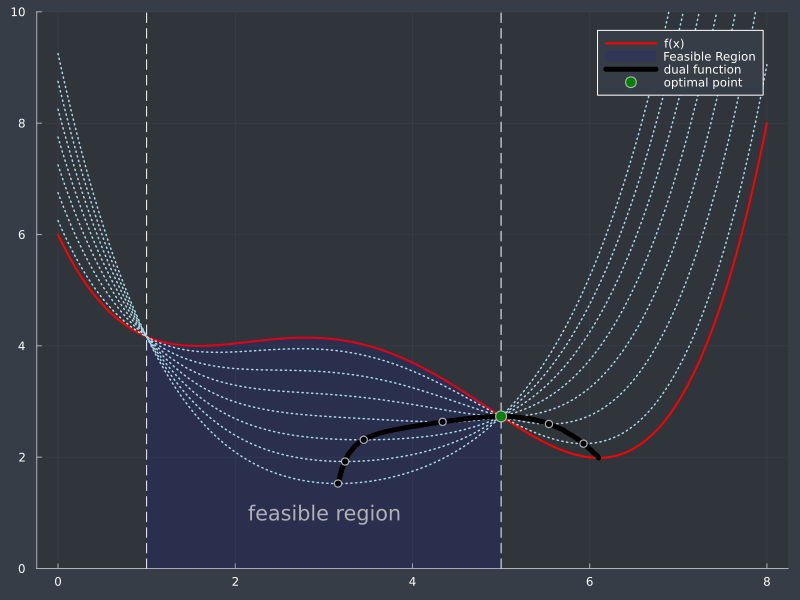

Figure 3: Plot of the Lagrange functions and the dual function

```julia
using Plots
using LaTeXStrings
theme(:dark)
default(size = (800, 600))  # set default plot size

# Define objective functions, constraint function, and Lagrangian
# (Coefficients obtained from polynomial interpolation)
f(x) = 0.0313178884607x^4 - 0.4376575805147x^3 + 1.9507119864263x^2 - 3.3803696303696x + 6.0
g(x) = 1/2 * (x-3)^2 - 2
L(x, λ) = f(x) + λ * g(x)

x_range = 0:0.01:8

# Plot objective function f
fig = plot(x_range, f, label="f(x)", c=:red, linewidth=2)

# Vertical lines to mark the feasible region
vline!(fig, [1], linestyle=:dash, linecolor=:white, label="")
vline!(fig, [5], linestyle=:dash, linecolor=:white, label="")

# Plot the feasible region
x_feasible = x_range[1 .<= x_range .&& x_range .<= 5]
f_feasible = f.(x_feasible)
plot!(fig, x_feasible, f_feasible, label="Feasible Region",
      fillrange=0, color=:blue, alpha=0.1,
      yrange=(0, 10), legend=:topright)
annotate!(fig, 3.0, 1.0, "feasible region")


# Function to determine the optimal x for a given Lagrange function
x_optimal_for_lambda(λ) = x_range[argmin(L.(x_range, λ))]

# Plot the Lagrangian for different lambdas
for λ in [0.1, 0.3, 0.5, 0.7, 0.9, 1.1, 1.3]
    plot!(fig, x_range, L.(x_range, λ), label="",
          c=:lightblue, linewidth=1.5, linestyle=:dot)
end

# Get the optimal point of the Lagragian with given lambda
function dual_function_parametric(λ)
    x_min = x_optimal_for_lambda(λ)
    y_min = L(x_min, λ)
    return x_min, y_min
end

lambda_range = 0:0.01:1.3
points_tuple_array = dual_function_parametric.(lambda_range)

# Extract x and y coordinates
x_coords = first.(points_tuple_array)
y_coords = last.(points_tuple_array)

# Plot dual function
plot!(fig, x_coords, y_coords, c="black", linewidth=5, label="dual function")

# Scatter plot for the optima of the Lagrangian
for λ in [0.1, 0.3, 0.7, 0.9, 1.1, 1.3]
    x_min = x_optimal_for_lambda(λ)
    y_min = L(x_min, λ)
    scatter!(fig, [x_min], [y_min], label="", c=:black, markersize=4)
end

# Plot the optimal point
scatter!(fig, [5], [f(5)], markersize=6, color=:green, label="optimal point")

# Don't forget to display the plot
display(fig)
```

### Examples for the Lagrangian

**NoteExamples for the Lagrangian**

Consider the following optimization problem:
$$\begin{aligned}
\text{minimize} &\quad \exp(x) - x \\
\text{such that} &\quad x + 1 \leq 0
\end{aligned}$$

. . .

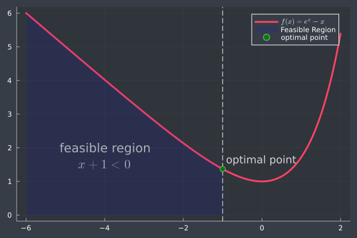

Figure 4: Plot of the optimization problem

```julia
using Plots
using LaTeXStrings
theme(:dark)

x_range = -6:0.01:2
f(x) = exp(x) - x

# Plot objective function f
plot(x_range, f, linewidth=3, label=L"f(x)=e^x - x")

# Plot vertical lines to mark the boundary of the feasible region
vline!([-1], linestyle=:dash, linecolor=:white, label="")

# Plot the feasible region
x_feasible = x_range[x_range .<= -1]
f_feasible = f.(x_feasible)
plot!(x_feasible, f_feasible, label="Feasible Region",
      fillrange=0, color=:blue, alpha=0.1,
      legend=:topright)
annotate!(-4.0, 2.0, "feasible region")
annotate!(-4, 1.5, L"x + 1 < 0")

# Plot optimal point
scatter!([-1], [f(-1)], c=:green, markersize=5, label="optimal point")
annotate!(-0.9, f(-1) + 0.1, text("optimal point", :lightgray, :bottom, :left, 12))
```

. . .

The Lagrangian is given by:

$$\begin{aligned}
L(x; \lambda) &= f(x) + \lambda g(x), \qquad \lambda \gt 0 \\
&= e^x + ( \lambda - 1) x + \lambda
\end{aligned}$$

. . .

The optimal $x$ can be found through differentiation:

$$\begin{aligned}
\frac{\mathrm{d}}{\mathrm{d}x} L(x; \lambda) &= e^x + (\lambda - 1) \overset{\text{!}}{=} 0 \\
\therefore \quad x_\text{opt}(\lambda) &= \ln(1 - \lambda), \qquad \lambda < 1
\end{aligned}$$

. . .

Substitue $x_\text{opt}$ for $x$ to obtain the dual function $q(\lambda)$:

$$\begin{aligned}
q(\lambda) &= L(x_\text{opt}, \lambda) \\
&= \exp\bigr(\ln( 1 - \lambda) \bigr) + (\lambda - 1) \ln( 1 - \lambda) + \lambda \\
&= (\lambda - 1) \ln( 1 - \lambda ) + 1, \qquad 0 \lt \lambda \lt 1
\end{aligned}$$

. . .

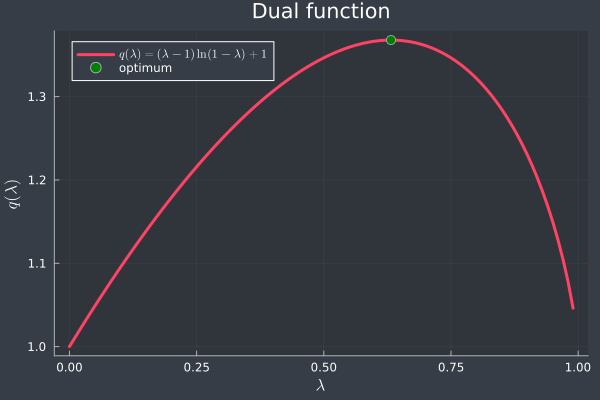

Figure 5: Plot of the dual function for the optimization problem

```julia
using Plots
using LaTeXStrings
theme(:dark)

lambda_range = 0:0.01:0.99  # q(-1) = -Inf
q(λ) = (λ - 1) * log(1 - λ) + 1

# Plot the dual function
plot(lambda_range, q, label=L"q(\lambda) = (\lambda - 1) \ln(1 - \lambda) + 1", linewidth=3)

# Plot the optimum
λ_opt = 1 - exp(-1)
scatter!([λ_opt], [q(λ_opt)], c=:green, markersize=5, label="optimum")

# Title and axis labels
title!("Dual function")
xlabel!(L"\lambda")
ylabel!(L"q(\lambda)")
```

. . .

Find the optimal Lagrange parameter $\lambda$:

$$\begin{aligned}
q'(\lambda) = 1 \cdot \ln( 1 - \lambda ) + (\lambda - 1) \frac{1}{1-\lambda} \cdot (-1) \overset{\text{!}}{=} 0 \\
\ln(1-\lambda) + 1 = 0 \\
\lambda_\text{opt} = 1 - e^{-1}
\end{aligned}$$

. . .

Thus, the optimal point for the optimization problem in stadard form is:

$$x_\text{opt} = \ln(1 - \lambda_\text{opt}) = \ln ( 1 - (1 - e^{-1})) = \ln(e^{-1}) = -1$$

Looking at Figure 4, this result is exactly as expected.

## Connection between the Lagrange dual function and the conjugate function

Remember that the dual function of a function $f$ is defined by

$$f^\ast (\mathbf{y} ) := \sup_{\mathbf{x}} \bigl\{ \mathbf{y}^\mathrm{T} \mathbf{x} - f(\mathbf{x}) \bigr\}$$

. . .

The Lagrange function and the conjugate function are related.

Consider the optimization problem

$$\begin{aligned}
\text{minimize} && f(\mathbf{x}) \\
\text{subject to} && \mathbf{x} = 0
\end{aligned}$$

Then the Langrage dual function is:
$$q(\boldsymbol{\lambda} ) = \inf_{\mathbf{x}} \bigl\{ f(\mathbf{x}) + \boldsymbol{\lambda}^\mathrm{T} \mathbf{x} \bigr\} = - \inf_\mathbf{x} \bigl\{ \boldsymbol{\lambda}^\mathrm{T} \mathbf{x} - f(\mathbf{x}) \bigr\} = - f^\ast(- \boldsymbol{\lambda})$$

[figure not shown]

Classical illustration for a positive duality gap  
source: [Dissecting the Duality Gap](https://link.springer.com/article/10.1007/s11590-021-01764-7/figures/2) [1] author: Nils-Hassan Quttineh, Torbjörn Larsson  
license: [CC BY 4.0](https://creativecommons.org/licenses/by/4.0/)

Interpration: Saddle Point, Game Theory

## TODO

- **Epigraph problem**
- Dual Problems (Boyd chapter 4)
- sufficient condition: $\nabla f(\hat{x}) = 0$ and $H f(\hat{x})$ pos. definit, then local minimum
- Optimization algorithms: iterative. Typees: gradient based, trust-region,

## References

[1]

N.-H. Quttineh and T. Larsson, “Dissecting the duality gap: The supporting hyperplane interpretation revisited,” *Optim Lett*, vol. 16, no. 3, pp. 1093–1102, Apr. 2022, doi: 10.1007/s11590-021-01764-7.